# **Panorama da inflação**

Os principais índices de inflação do Brasil, apontam em outubro de 2002 um avanço da inflação de em média **2.25%**. Com esse resultado, no ano a inflação acumula uma variação média positiva de **9.82%**, e em 12 meses uma variação média acumulada de **11.68%**.

[output not shown]

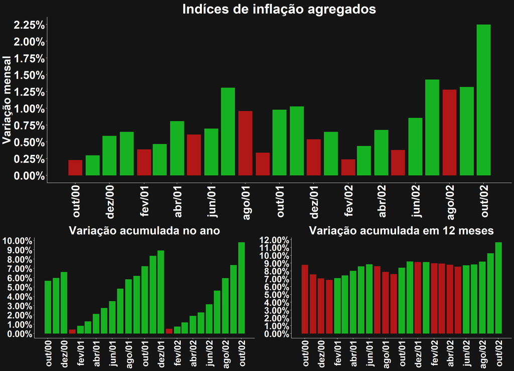

Índices selecionados para a média: IPCA, INPC e IGP-M.

# IPCA

O Indíce de Preços ao Consumidor Amplo (IPCA) variou 1.31% em outubro, valor superior ao mesmo período do ano anterior quando apresentou uma taxa de 0.83%. Com esse resultado o indíce acumula no ano uma variação positiva de 6.98%, e em 12 meses uma variação positiva de 8.45%.

|  | 10/2001 | 09/2002 | 10/2002 |
| --- | --- | --- | --- |
| Variação mensal | 0.83% | 0.72% | 1.31% |
| Variação acumulada no ano | 6.22% | 5.6% | 6.98% |
| Variação acumulada em 12 meses | 7.19% | 7.93% | 8.45% |

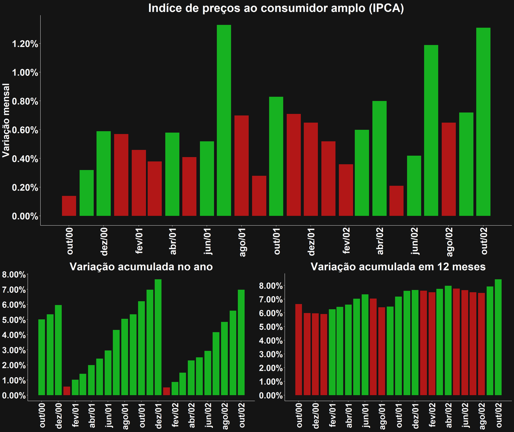

|  | Variação mensal | Variação acumulada no ano | Peso mensal |
| --- | --- | --- | --- |
| Alimentação e bebidas | 2.79% | 8.61% | 22.41% |
| Habitação | 0.3% | 9.2% | 16.55% |
| Artigos de residência | 2.27% | 7.54% | 5.68% |
| Vestuário | 1.22% | 6.78% | 5.37% |
| Transportes | 1.2% | 3.67% | 21.42% |
| Saúde e cuidados pessoais | 0.63% | 6.32% | 10.64% |
| Despesas pessoais | 1.12% | 5.61% | 9.39% |
| Educação | 0.13% | 7.88% | 4.87% |
| Comunicação | 0.06% | 11.2% | 3.67% |

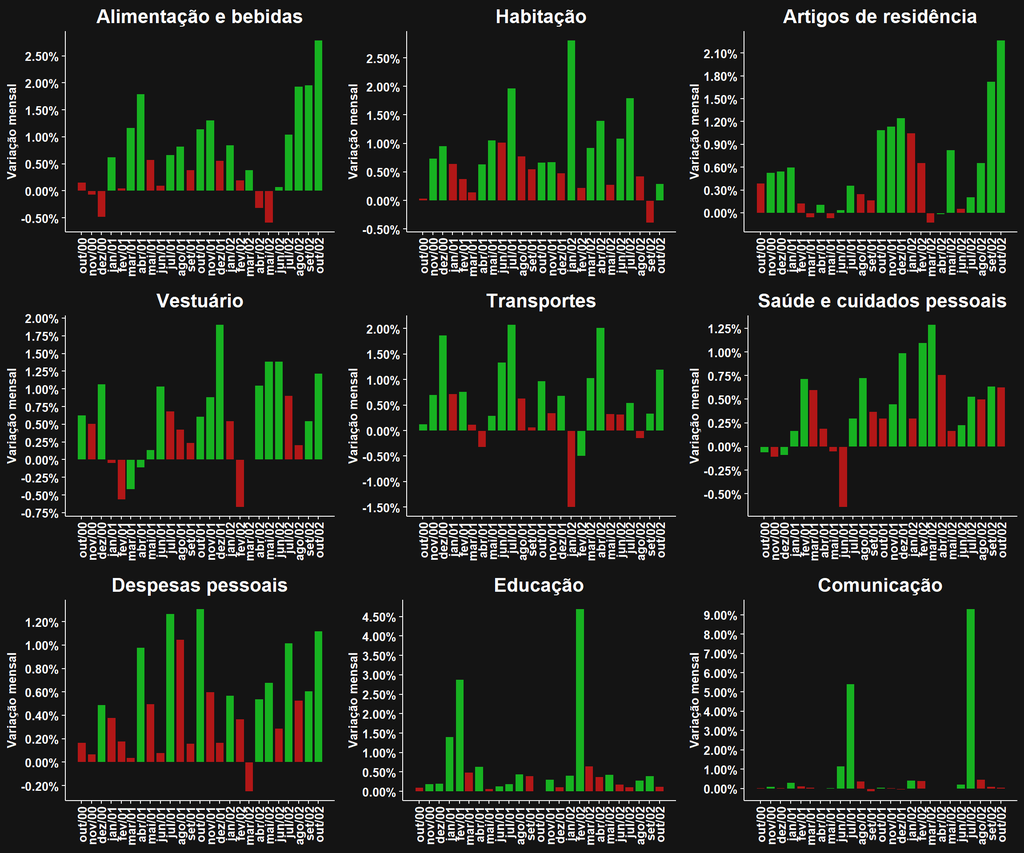

A nível de sub-itens os que mais influenciaram positivamente no resultado em relação ao seu peso foram Pão francês (6.37%%) e Etanol (11%%), e negativamente Automóvel novo (-0.96%%) e Tomate (-6%%).

|  | Variação mensal | Variação acumulada no ano | Peso mensal |
| --- | --- | --- | --- |
| Arroz | 9.03% | 12.16% | 0.77% |
| Pão francês | 6.37% | 26.28% | 1.57% |
| Etanol | 11% | 1.09% | 0.87% |
| Gasolina | 1.78% | 0.14% | 4.09% |

|  | Variação mensal | Variação acumulada no ano | Peso mensal |
| --- | --- | --- | --- |
| Conserto de automóvel | -0.43% | 1.96% | 1.45% |
| Automóvel novo | -0.96% | -2.53% | 3.19% |
| Alho | -5.42% | 12.91% | 0.08% |
| Tomate | -6% | 19.5% | 0.11% |

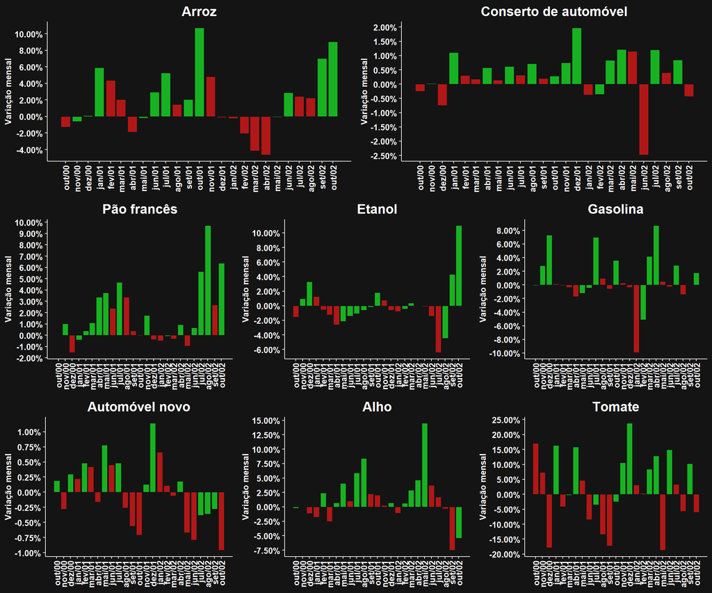

# INPC

O Indíce Nacional de Preços ao Consumidor (INPC) variou 1.57% em outubro, valor superior ao mesmo período do ano anterior quando apresentou uma taxa de 0.94%. Com esse resultado o indíce acumula no ano uma variação positiva de 8.06%, e em 12 meses uma variação positiva de 10.26%.

|  | 10/2001 | 09/2002 | 10/2002 |
| --- | --- | --- | --- |
| Variação mensal | 0.94% | 0.83% | 1.57% |
| Variação acumulada no ano | 7.25% | 6.39% | 8.06% |
| Variação acumulada em 12 meses | 8.16% | 9.58% | 10.26% |

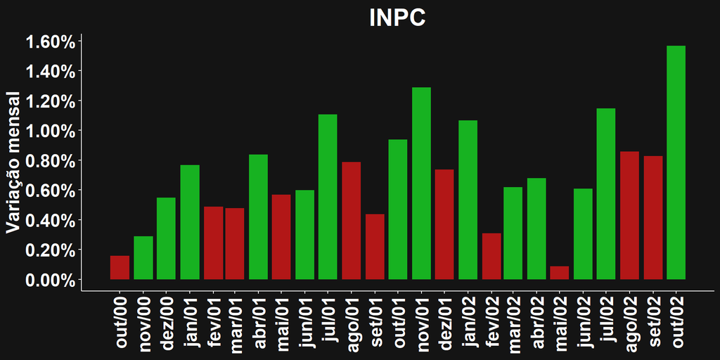

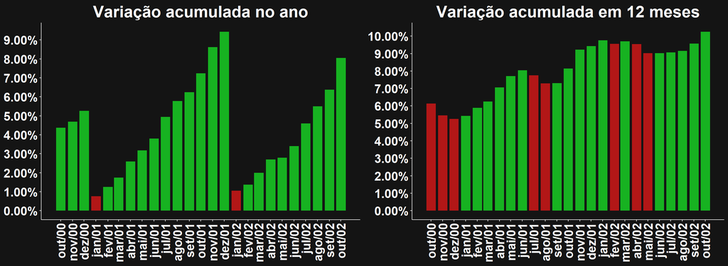

# IGP-M

O Indíce Geral de Preços de Mercado (IGP-M) variou 3.87% em outubro, valor superior ao mesmo período do ano anterior quando apresentou uma taxa de 1.18%. Com esse resultado o indíce acumula no ano uma variação positiva de 14.41%, e em 12 meses uma variação positiva de 16.34%.

|  | 10/2001 | 09/2002 | 10/2002 |
| --- | --- | --- | --- |
| Variação mensal | 1.18% | 2.4% | 3.87% |
| Variação acumulada no ano | 8.27% | 10.14% | 14.41% |
| Variação acumulada em 12 meses | 9.95% | 13.32% | 16.34% |

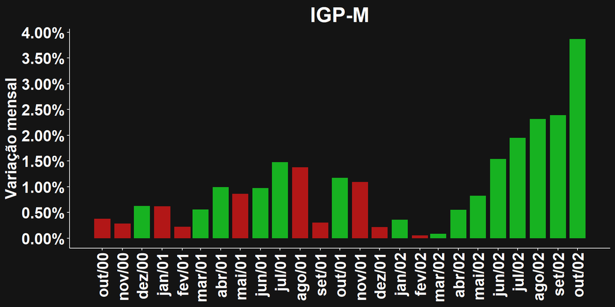

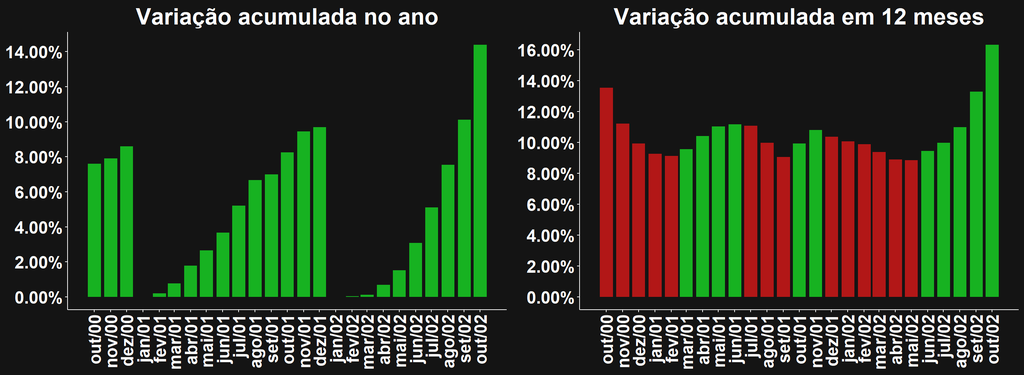

# IGP-DI

O Indíce Geral de Preços - Disponibilidade Interna (IGP-DI) variou 4.21% em outubro, valor superior ao mesmo período do ano anterior quando apresentou uma taxa de 1.45%. Com esse resultado o indíce acumula no ano uma variação positiva de 16.08%, e em 12 meses uma variação positiva de 17.4%.

|  | 10/2001 | 09/2002 | 10/2002 |
| --- | --- | --- | --- |
| Variação mensal | 1.45% | 2.64% | 4.21% |
| Variação acumulada no ano | 8.83% | 11.39% | 16.08% |
| Variação acumulada em 12 meses | 10.62% | 14.28% | 17.4% |

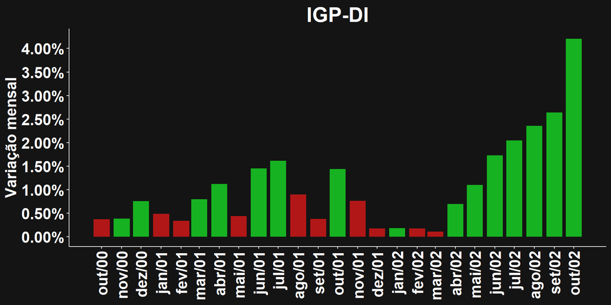

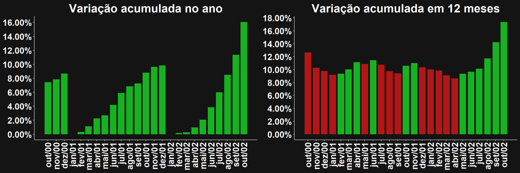

[output not shown]

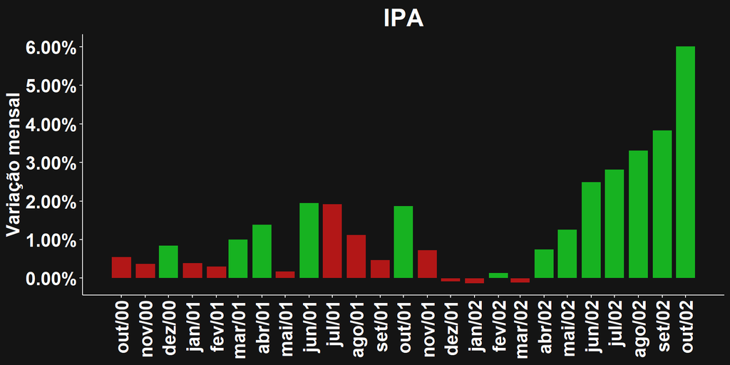

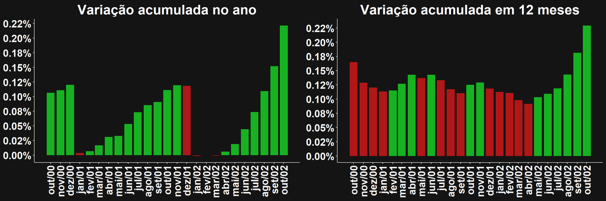

O Indíce de Preços ao Consumidor (IPC), integrante do IGP-DI com peso de 30%, apresentou variação de 1.14% em outubro, valor superior ao mesmo período do ano anterior quando apresentou uma taxa de 0.71%. Com esse resultado o indíce acumula no ano uma variação positiva de 5.85%, e em 12 meses uma variação positiva de 8.35%.

|  | 10/2001 | 09/2002 | 10/2002 |
| --- | --- | --- | --- |
| Variação mensal | 0.71% | 0.66% | 1.14% |
| Variação acumulada no ano | 5.61% | 4.65% | 5.85% |
| Variação acumulada em 12 meses | 7.38% | 7.89% | 8.35% |

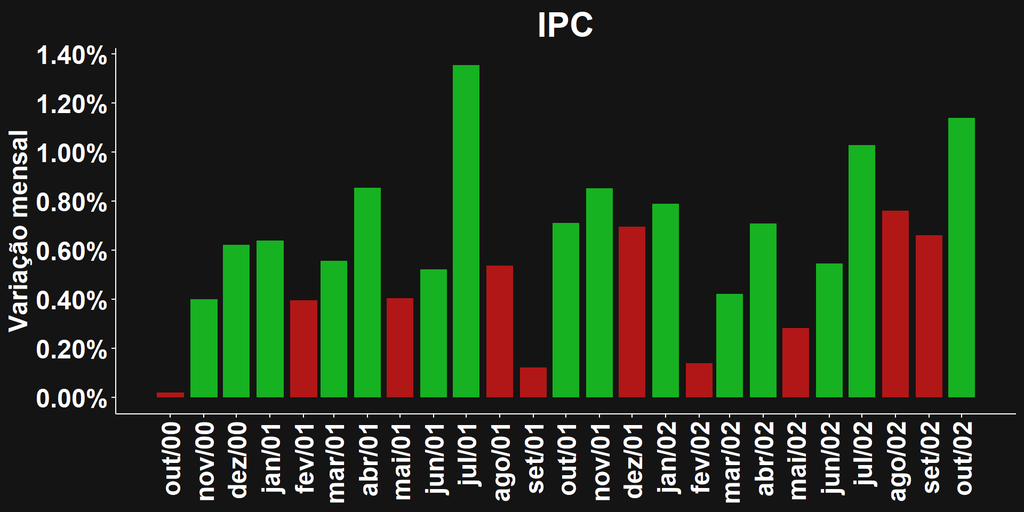

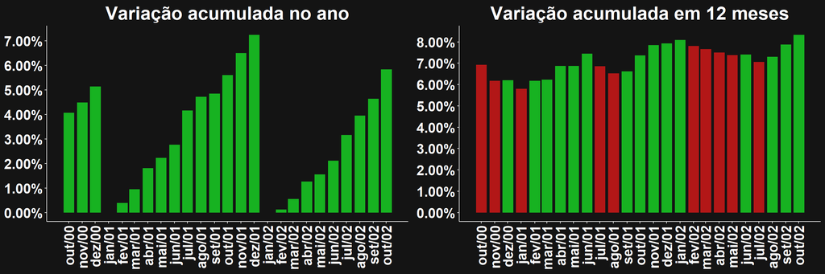

O Indíce Nacional de Custos de Construção (INCC), integrante do IGP-DI com peso de 10%, apresentou variação de 1.13% em outubro, valor superior ao mesmo período do ano anterior quando apresentou uma taxa de 0.93%. Com esse resultado o indíce acumula no ano uma variação positiva de 7.94%, e em 12 meses uma variação positiva de 9.49%.

|  | 10/2001 | 09/2002 | 10/2002 |
| --- | --- | --- | --- |
| Variação mensal | 0.93% | 0.71% | 1.13% |
| Variação acumulada no ano | 7.07% | 6.73% | 7.94% |
| Variação acumulada em 12 meses | 8.83% | 9.28% | 9.49% |

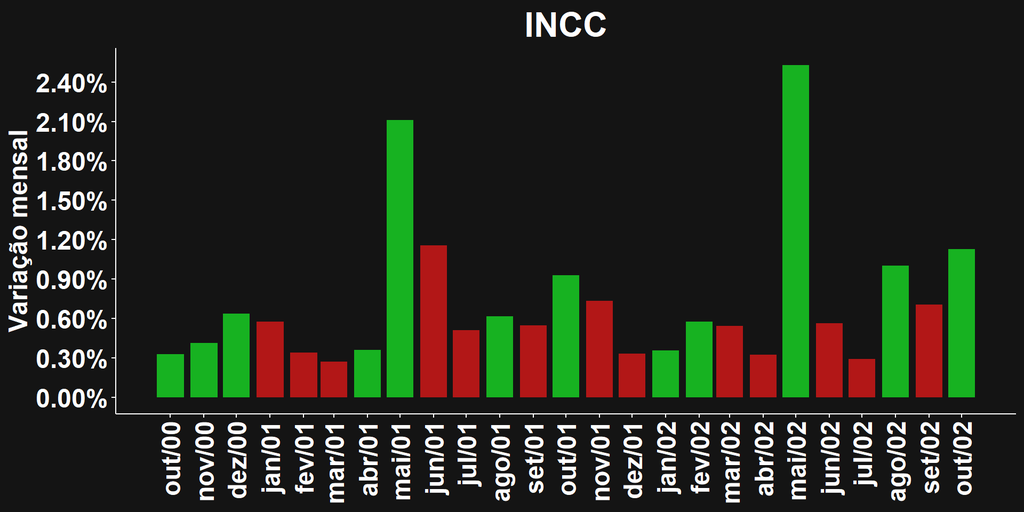

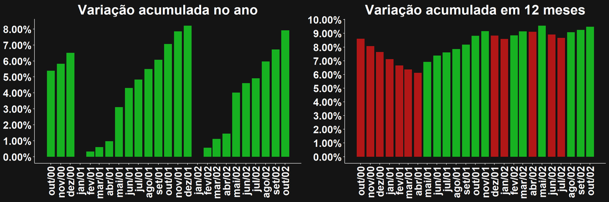

# Estatísticas

As estatísticas descritivas a seguir são feitas com base nos últimos 48 meses, e tem como objetivo possibilitar a avaliação do resultado observado em comparação aos períodos anteriores.

|  | Minimo | 1 Quartil | Mediana | Media | 3 Quartil | Maximo | Desvio Padrão |
| --- | --- | --- | --- | --- | --- | --- | --- |
| IPCA | -0.12% | 0.32% | 0.56% | 0.6% | 0.74% | 1.61% | 0.38% |
| INPC | -0.18% | 0.37% | 0.61% | 0.63% | 0.88% | 1.57% | 0.41% |
| IGP-M | -0.32% | 0.36% | 0.86% | 1.09% | 1.55% | 3.87% | 0.94% |
| IGP-DI | -0.34% | 0.38% | 0.96% | 1.12% | 1.6% | 4.44% | 1% |
| IPA | -0.82% | 0.36% | 1.2% | 1.47% | 2.19% | 6.99% | 1.55% |
| IPC | -0.19% | 0.37% | 0.58% | 0.6% | 0.85% | 1.91% | 0.42% |
| INCC | -0.05% | 0.38% | 0.57% | 0.68% | 0.88% | 2.53% | 0.46% |

Levando em consideração o desvio padrão de cada indíce, proporcionalmente os que mais se afastaram da média foram o IGP-DI, o IGP-M e o IPA.

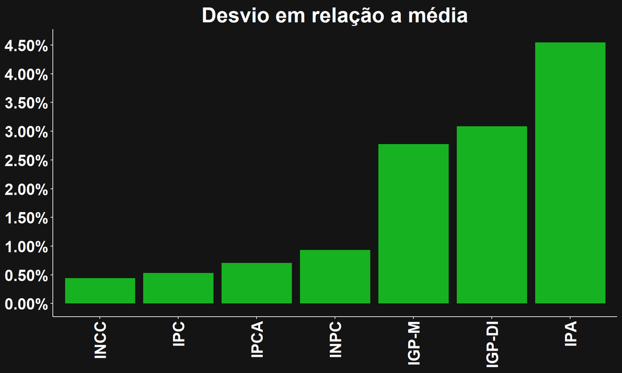

**João Victor Gomes**  
**jvg.santana@gmail.com**  
**[linkedin.com/in/jvictorgomes](https://www.linkedin.com/in/jvictorgomes/)**